# Web Scraping with R (3): Scraping twiter for Sentiment Analysis

Alex Sanchez (asanchez@ub.edu)  
GME Department. Universitat de Barcelona  
Statistics and Bioinformatics Unit. Vall d’Hebron Institut de Recerca

# Readme

- License: Creative Commons Attribution-NonCommercial-ShareAlike 4.0 International License http://creativecommons.org/licenses/by-nc-sa/4.0/
- You are free to:
  - **Share** : copy and redistribute the material
  - **Adapt** : rebuild and transform the material
- Under the following conditions:
  - **Attribution** : You must give appropriate credit, provide a link to the license, and indicate if changes were made.
  - **NonCommercial** : You may not use this work for commercial purposes.
  - **Share Alike** : If you remix, transform, or build upon this work, you must distribute your contributions under the same license to this one.

# Disclaimer and acknowledgements

- These slides have been prepared based on multiple sources: websites, blogs, courses. While it is hard to cite them all I wish to acknowledge those sources that have been particularly useful.
  - [Tutorial-R-web-data](https://github.com/gastonstat/tutorial-R-web-data), by Gaston Sanchez
  - [Text Mining, Scraping and Sentiment Analysis with R](https://www.udemy.com/r-social-media-mining-scraping-with-twitter/) Udemy.
  - [Working with Web Data in R](https://www.datacamp.com/courses/working-with-web-data-in-r) Datacamp Course

# Installing necessary R packages

- For the purpose of this chapter, we will need the following packages:
  - `ROAuth`: Provides an interface to the OAuth 1.0 specification, allowing users to authenticate via OAuth to the server of their choice.
  - `httr`: Useful tools for working with the HTTP protocol. allows alternative authentication.
  - `twitteR`: Provides an interface to the Twitter web API.
  - `tm`: Text mining package.
- Start by installing and loading all the required packages.

```r
> if(!require(dplyr)) install.packages("dplyr")
> if(!require(stringr)) install.packages("stringr")
> if (!require(twitteR)) install.packages("twitteR")
> # if (!require(ROAuth)) install.packages("ROAuth")
> # if (!require(httr)) install.packages("httr")
> if (!require(tm)) install.packages("tm")
> if (! require(wordcloud) ) install.packages("wordcloud")
```

# Introduction: Scraping Twitter for Sentiment Analysis

- Social networks like Twitter provide an excellent environment for web scraping:
  - They contain “interesting” data (e.g. *trending topics*, )
  - The data is not readily available, so getting it is a challenge in itself, but there are *packages and tools that can facilitate the process*.
  - The analysis of textual data extracted from Twitter requires techniques that are not common in the statistician’s toolbox, so *an introduction to Textual and to Sentiment Analysis* will be offered.

# How can we analyze natural language (text)

- Textual analysis is an [old friend](http://www.raco.cat/index.php/anuariopsicologia/article/viewFile/61168/88733) of statistics, especially in the french school, especially in social sciences (i.e. analysis of answers to open questions in surveys).
- R’s [Natural Language Processing Task View](https://cran.r-project.org/web/views/NaturalLanguageProcessing.html) collects R packages to support conducting analysis of *speech* and *language* on a variety of levels.
- [**`tm`**](https://cran.r-project.org/web/packages/tm/index.html), “Text Mining Package” is one of the main packages available for this type of tasks.
- **`tm`** incorporates functions for reading text corpus and “breaking” them in different ways that facilitate their analysis
  - most of the times it starts by some type cleaning followed by
  - the analysis of diverse frequency tabulations.
- A simple case study can be found here: https://jhuria.wordpress.com/2012/07/01/text-mining-in-r/

# Linking Text Mining and Web Scraping

- Text mining can be done, of course, in a web-independent manner.
- Alternatively, if one takes into account that the web is populated with all types of (unstructured) text, the relation becomes obvious.
- See the “Social Media Clients” section in the Web Technologies Task View in CRAN ([Site](https://cran.r-project.org/web/views/WebTechnologies.html), [Description](https://journal.r-project.org/archive/2014-1/mair-chamberlain.pdf)) for a variety of packages that facilitate the connection with diverse source of data, such as Google, Facebook, Twitter, or Amazon which provide APIs which allow analysts to retrieve data.

# Preparing data acquisition from twitter

- In order to extract tweets, one needs a *Twitter application* and hence a *Twitter account*. If you don’t have a Twitter account, please sign up.
- Use your Twitter login ID and password to sign in at [Twitter Developers](https://apps.twitter.com/).
- Once you have signed in both accounts (Twitter –> Twitter developers) you can start to *“Create New App”*
  - Provide the necessary details (notice that some are compulsory and some are not)
  - Agree to the developer Agreement
- As you have created this app you have been provided with a series of keys, accessible from the “Keys and Tokens”, tab that **need to be used** to authenticate, that is grant you access, so that you can retrieve bunchs of tweets.

# Authentication (1): Access tokens

- In order to be able to recover tweets “massively” we need to be granted access. This is called “authentication”.
- The following objects from the “keys and access token” tab in the developers account are provided after an application has been created
  - key <- “your API key from twitter”
  - secret <- “your Secret key from twitter”
  - secrettk <- “Access Token Secret from Twitter”
  - mytoken <- “Access Token from Twitter”

```r
> # Use this code chunk to assign values to these 4 variables.
> # The values can be obtained from **your** twitter developer account.
> key <- XXXX         # "your API key from twitter"
> secret <-   XXXX  # "your Secret key from twitter"
> mytoken <-  XXXX    # "Access Token from Twitter"
> secrettk <- XXXX   # "Access Token Secret from Twitter"
```

# Authentication (2)

- For the authentication we will also use the `setup_twitter_oauth` function (`?setup_twitter_oauth`)

```r
> require(twitteR)
> setup_twitter_oauth(consumer_key = key, consumer_secret = secret,
+                     access_token= mytoken, access_secret=secretoken)
```

```
[1] "Using direct authentication"
```

```r
>  # (1) choose direct authentication and answer "Yes"
```

This should let you connected so that you can start searching twitter.

The connection can be tested with a simple search whose meaning will be explained in the following slides.

```r
> searchTwitter("#beer", n=10)
```

```
[[1]]
[1] "BigCityDiner: RT @BCDlane: Check out our @BigCityDiner at @KailuaTownHi &amp; @WaipioCenter LIVE MUSIC lineup for the month of April...See you FRIDAY for #On…"

[[2]]
[1] "BigCityDiner: RT @BCDlane: Join us for Happy \"Pau Hana\" Hour at @BigCityDiner at @WardVillage @Pearlridge @MyKailua808 &amp; @KaimukiHi for $4 Coronas + 50%…"

[[3]]
[1] "Hipfig: #konabrewingco #kailua #hawaii #bigisland\ncold #beer on a #hot #day\nPerfect finish after a long day… https://t.co/sgsvuYMT4O"

[[4]]
[1] "dteamerdk: #today #봄 #spring #날씨 #weather #대한민국 #korea #korean #서울 #seoul #강남 #홍대 #university #맛집 에서 #맛점 #lunch #party #바다… https://t.co/LjZ2qzZQo4"

[[5]]
[1] "PopTatesIndia: Thrillers are meant to be watched over Killer dishes. We’ve got ‘em all at #PopTates: https://t.co/6kbdMEdu38… https://t.co/NRvire6WKe"

[[6]]
[1] "bhspune: Our signature ‘Monalisa’ is guaranteed to leave you ‘smiling’. Pair it up with our chilled #beer by hopper to beat… https://t.co/RR8Cz1EtRH"

[[7]]
[1] "TCBeerNGunClub: 1310. To The other worlds. Yet #beer"

[[8]]
[1] "kagoyasake: 「籠屋」 地酒新着情報  マルスウイスキー エクストラ  https://t.co/HVdOM4xT7K  #sake   #shouchu  #wine  #sakaya  #nihonsyu  #beer  #whis"

[[9]]
[1] "MarketLiquors: RT @FetchtheCity: Pop A Cold One Over Champions League Tonight For Just R229.99 For A 24 Pack Windhoek Beer Courtesy Of @MarketLiquors http…"

[[10]]
[1] "MaximusCampers: The Time It Takes To Down Your First #Beer Is The #Time It Takes \nTo #SetUp #MaximusUltimateCamperTrailer.… https://t.co/5xkFItWg8j"
```

If something is returned it means the system is working.

# Package overview

- The `twitteR` vignette provides an overview of the main functionalities of the package:
1. Search Twitter: `searchTwitter()`
2. Look at users : `getUser()`
3. Manipulate grabbed tweets (convert to data.frames): `twListToDF()`
4. Timelines (streams of tweets): `userTimeline()`
5. Explore Trends: `getTrends()`

# An overview of the process

- A typical information extraction process may be the following:
1. Extract tweets and followers from the Twitter website with R and the `twitteR` package.
2. Clean text by removing punctuations, numbers, hyperlinks and stop words.
- This will be followed by *a variety* of possible analyses:
3. Build a term-document matrix and make a Word Cloud.
4. Analyse topics with the `topicmodels` package.
5. Analyse sentiment with the `sentiment140` package.
6. Analyse following/followed and retweeting relationships with the `igraph` package

# Extract tweets

- Start setting twitter and authenticating as described in the previous steps.
- Information acquisition with the `twitteR` package is based on the `searchTwitter` function.
- It is recommended to read the official Twitter Search API documentation https://dev.twitter.com/rest/public/search
  - You will find things such as: *The Twitter Search API searches against a sampling of recent Tweets published in the past 7 days*. So do not try to llok for tweets older than a week!

# 1. Extract tweets (continued)

- We start with a simple search on a “popular” topic

```r
> require(twitteR)
> search.string <- "#Brexit"
> no.of.tweets <- 1000
> aTopicTweets <- searchTwitter(search.string, n=no.of.tweets, lang="en",
+                           since='2019-04-01', until='2019-04-10')
> head(aTopicTweets)
> save(aTopicTweets, file="aTopicTweets.Rda")
```

Alternatively we can search (at most) recent tweets from a given user.

```r
> aUser <- "nntaleb" # f2harrell
> aUserTweets <- userTimeline(aUser, n = 3200)
> save(aUserTweets, file="aUserTweets.Rda")
```

# 2. Clean up text (1)

- The product of the scraping process is a list with the “raw” content of each tweet.
- Before we do any analysis we usually want to clean the text.
- Although this may be done using the `tm` package it may be clearer to understand if we “simply” rely on regular expressions.

# 2. Clean up text (1b): Code

```r
> require(twitteR)
> showTweets <- TRUE
> if (!exists("aTopicTweets")) load("aTopicTweets.Rda")
>  tweets.text <- sapply(aTopicTweets, function(x) x$getText())
>  # Replace @UserName
>  tweets.text <- gsub("@\\w+", "", tweets.text)
>  # Remove punctuation
>  tweets.text <- gsub("[[:punct:]]", "", tweets.text)
>  # Remove links
>  tweets.text <- gsub("http\\w+", "", tweets.text)
>  # Remove tabs
>  tweets.text <- gsub("[ |\t]{2,}", "", tweets.text)
>  # remove codes that are neither characters nor digits
>  tweets.text<-  gsub( '[^A-z0-9_]', ' ', tweets.text)
>  # Set characters to lowercase
>  tweets.text <- tolower(tweets.text)
>  # Replace blank space (“rt”)
>  tweets.text <- gsub("rt", "", tweets.text)
>  # Remove blank spaces at the beginning
>  tweets.text <- gsub("^ ", "", tweets.text)
>  # Remove blank spaces at the end
>  tweets.text <- gsub(" $", "", tweets.text)
>  head(tweets.text)
```

```
[1] "if brexit is april 12th we have2 days 21 hours 59 minutes and 59 secondsbrexit brexitclock clock eu euref leave"
[2] "nobody voted for this mess i blame the charlatans who peddled the falsehoods that brexit would be easy i wouldnt t"
[3] "german in london said to me yesterday if a foreign power had done as much damage to your country as your country has don"
[4] "this is unacceptable amp indeed a disgracethe shame of brexit mounts each day this is not our great country   time to"
[5] "on 10 april eu leaders will discuss brexit at a special euco aicle50 summit in brussels check out our interactive sto"
[6] "new campaignersare plastering european commission building in brussels tonight with images of tweets from"
```

# 2. Clean the text (2a): Remove “common words”

- Once the text has been cleaned it may be “pruned” from words that are known to be non-relevant.
- An example are commonly used words such as “a” or “the”.
- Such terms are known as “Stop words” and we usually obtain them from some place where they have been compiled.
- The `tm` package contains an instance of such list that can be recovered with the `stopwords` function.
- The `tm` package represents texts as *collections of documents* which are called “corpus”.

# 2. Clean the text (2b): Code for removing `stopwords`

```r
> require("tm")
> #create corpus
> tweets.text.corpus <- Corpus(VectorSource(tweets.text))
> head(stopwords())
```

```
[1] "i"      "me"     "my"     "myself" "we"     "our"
```

```r
> #clean up by removing stop words
> tweets.text.corpus <- tm_map(tweets.text.corpus, function(x) removeWords(x, stopwords()))
> head(tweets.text.corpus)
```

```
<<SimpleCorpus>>
Metadata:  corpus specific: 1, document level (indexed): 0
Content:  documents: 6
```

# Textual Analysis (1) Visualize tweets as Word Cloud

- A simple visualization can be obtained using a “cloud of words”.
- This can be done with the `wordcloud` package.

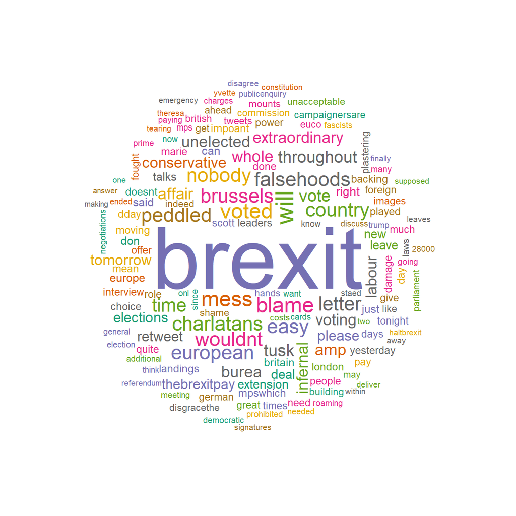

```r
> #generate wordcloud
> require(wordcloud)
> wordcloud(tweets.text.corpus, min.freq = 2, scale=c(7,0.5),
+ colors=brewer.pal(8, "Dark2"),random.color= TRUE, random.order = FALSE,
+ max.words = 150)
```

# Textual Analysis (2) Visualize counts and groups

- A more classical visualization can also be obtained if one does a *simple* frequency analysis.

```r
> require(tm)
> #create corpus
> # mycorpus <- Corpus(VectorSource(tweets.text))
> # mytdm <- TermDocumentMatrix(mycorpus)
> mytdm <- TermDocumentMatrix(tweets.text.corpus)
> inspect(mytdm[1:15,1:30])
```

```
<<TermDocumentMatrix (terms: 15, documents: 30)>>
Non-/sparse entries: 52/398
Sparsity           : 88%
Maximal term length: 13
Weighting          : term frequency (tf)
Sample             :
             Docs
Terms         1 10 12 16 2 27 4 5 7 8
  12th        1  0  0  0 0  0 0 0 0 0
  april       1  0  0  0 0  0 0 1 0 0
  blame       0  1  1  1 1  1 0 0 0 1
  brexit      1  1  1  1 1  1 1 1 1 1
  brexitclock 1  0  0  0 0  0 0 0 0 0
  charlatans  0  1  1  1 1  1 0 0 0 1
  clock       1  0  0  0 0  0 0 0 0 0
  days        1  0  0  0 0  0 0 0 0 0
  easy        0  1  1  1 1  1 0 0 0 1
  leave       1  0  0  0 0  0 0 0 1 0
```

```r
> findFreqTerms(mytdm, lowfreq=55) # experiment with the lowfreq
```

```
 [1] "brexit"        "blame"         "charlatans"    "easy"
 [5] "falsehoods"    "mess"          "nobody"        "peddled"
 [9] "voted"         "wouldnt"       "country"       "amp"
[13] "time"          "brussels"      "will"          "european"
[17] "conservative"  "vote"          "tomorrow"      "elections"
[21] "voting"        "affair"        "burea"         "extraordinary"
[25] "infernal"      "letter"        "throughout"    "tusk"
[29] "unelected"     "whole"         "labour"        "please"
[33] "retweet"
```

```r
> tdm <-removeSparseTerms(mytdm, sparse=0.93) # experimet with sparse
```

# Textual Analysis (2) Visualize counts and groups

- Using the frequency counts obtained from the text corpus we can build a distance matrix and plot a dendrogram.

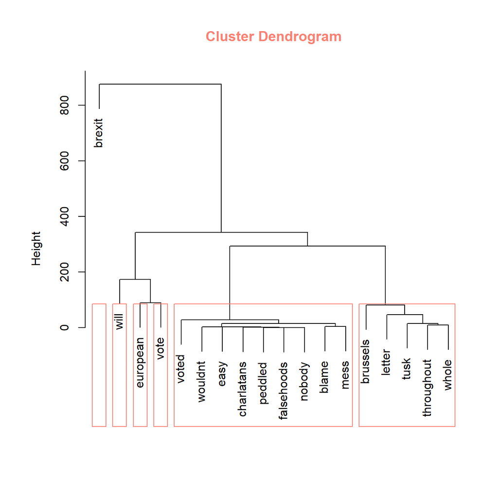

```r
> tdmscale <- scale(tdm)
> dist <- dist(tdmscale, method = "canberra")
> fit <- hclust(dist)
>
> # we need to change the margins and delete some titles
> par(mai=c(1,1.2,1,0.5))
> plot(fit, xlab="", sub="", col.main="salmon")
> rect.hclust(fit, k=6, border="salmon")
```

```r
> # cutree(fit, k=6)
```

# Sentiment Analysis

- Sentiment analysis is used to see if a text is neutral, positive or negative.
- Emotion analysis is used to see which emotion a text has (happy, fear, anger)
- Both are using similar codes but the comparison lexicon is different.
  - Example: What is the sentiment towards my company?
- Twitter data is useful for that type of analysis because:
  - high volumes (500 mill/day)
  - short messages like sms - 140 words
  - special strings (hashtags)
  - but creative word usage makes it hard for analysis, spelling mistakes
- There is **TONS** of sentiment in it!

# Sentiment lexicons

- Sentiment Lexicon: a list of words which you are using to compare your scraped text with.
- There exists a “standard list of words for sentiment analysis” compiled by Hu liu
- Essentially it is a list of positive and negative words created manually - approx. 6800
- Easy to find in te web but available in Atenea

```r
> pos <- readLines("Positive-Words.txt")
> pos[sample(1:length(pos), 5)]
```

```
[1] "solicitously" "ardent"       "worthy"       "excitingly"
[5] "properly"
```

```r
> neg <- readLines("Negative-Words.txt")
> neg[sample(1:length(neg), 5)]
```

```
[1] "shirker"        "conspiratorial" "fidget"         "hells"
[5] "sneak"
```

# Scoring function

- Positive and negative words may be scored using a simple ad-hoc function such as `score.sentiment` written by Jeff Breen.
- See its github repo on Sentiment analysis with R, [here](https://github.com/jeffreybreen/twitter-sentiment-analysis-tutorial-201107)

```r
> source("https://raw.githubusercontent.com/jeffreybreen/twitter-sentiment-analysis-tutorial-201107/master/R/sentiment.R")
```

Give a look at function `score.sentiment` to notice how simple is the idea for scoring sentiments.

# Using the function

- We are going to do sentiment analysis for a list of words that come from 4 tweeter searches.
- alternatively, if we were in an election time we could compare tweets about parties.

```r
> require(twitteR)
> usatweets = searchTwitter("usa", n=900, lang="en")
> indiatweets = searchTwitter("india", n=900, lang="en")
> russiatweets = searchTwitter("russia", n=900, lang="en")
> chinatweets = searchTwitter("china", n=900, lang="en")
> save(usatweets, indiatweets, russiatweets, chinatweets, file="countryTweets.Rda")
```

# Exploring country tweets

- We start getting the text and joining it into a single character vector

```r
> if (!exists("usatweets") )load(file="countryTweets.Rda")
> usa_txt = sapply(usatweets, function(x) x$getText())
> india_txt = sapply(indiatweets, function(x) x$getText())
> russia_txt = sapply(russiatweets, function(x) x$getText())
> china_txt = sapply(chinatweets, function(x) x$getText())
> country = c(usa_txt, india_txt, russia_txt, china_txt)
```

# Applying the `score.sentiment` function

```r
> countries <-  gsub( '[^A-z0-9_]', ' ', country)
> scores <- score.sentiment(countries, pos, neg, .progress='none')
> nd <- c(length(usa_txt), length(india_txt), length(russia_txt), length(china_txt))
> scores$country = factor(rep(c("usa", "india", "russia", "china"), nd))
> scores$very.pos = as.numeric(scores$score >= 2)
> scores$very.neg = as.numeric(scores$score <= -2)
> numpos = sum(scores$very.pos)
> numneg = sum(scores$very.neg)
```

# Exploring the scores (1)

```r
> head(scores)
```

```
  score
1     0
2     0
3     0
4     0
5     0
6    -3
                                                                                                                                            text
1           RT  girlshealth  Power up your  smoothies this summer by adding spinach or avocados  https   t co mLVWsUlSpk https   t co kZLZgu957N
2                                       PrisonPlanet  AmericaFirst We will Defend Our Country   USA  MAGA  UnitedWeStand https   t co xUs2vgyyKD
3                                          RT  mlnangalama   Bobby Three Sticks  Mueller to probe Russia Trump imbroglio https   t co Eb21LeTkR2
4     We re  hiring  Read about our latest  job opening here  Senior Account Executive   https   t co 9LgweOaeIU  Sales  ParsippanyTroyHills  NJ
5                         RT  V_of_Europe  Car plows into pedestrians at New York s Times Square https   t co JM1FmR1f6m https   t co 8HyBxbqynq
6 RT  ComedyOrTruth  18  can I buy a bottle of wine   USA  no that s illegal  amp  irresponsible  18  can I go  50 000 into debt for education
  country very.pos very.neg
1     usa        0        0
2     usa        0        0
3     usa        0        0
4     usa        0        0
5     usa        0        0
6     usa        0        1
```

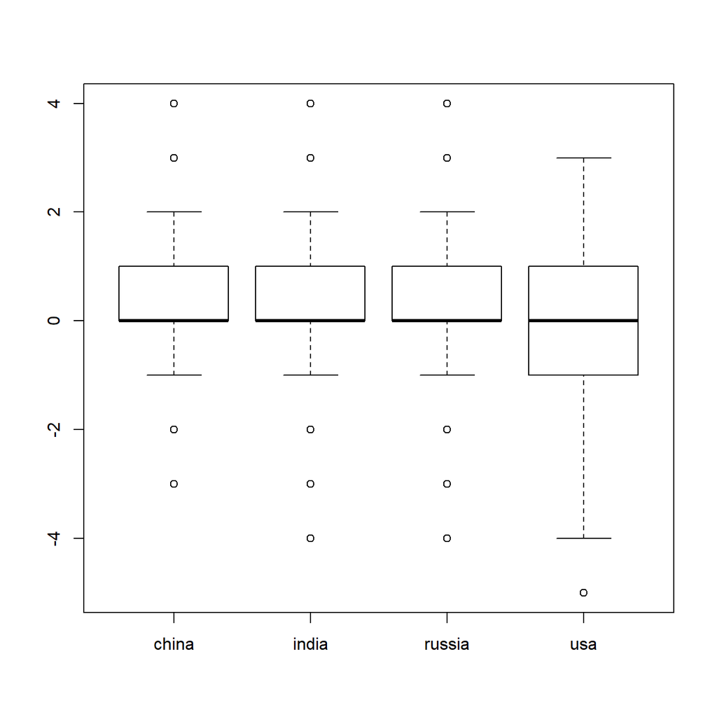

```r
> boxplot(score~country, data=scores)
```

# Exploring the scores (2)

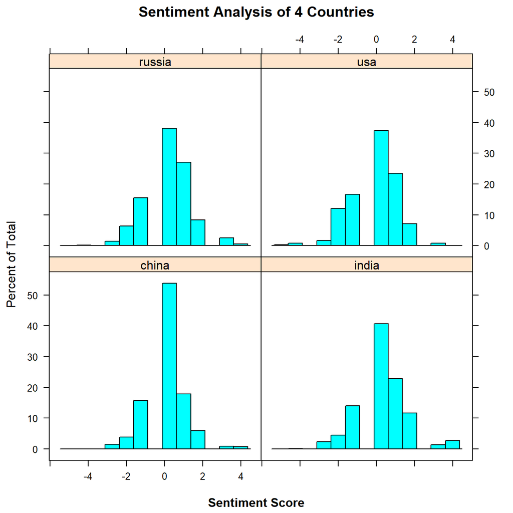

```r
> require(lattice)
> histogram(data=scores, ~score|country,
+ main="Sentiment Analysis of 4 Countries", xlab="", sub="Sentiment Score")
```